# Ungraded Lab: Predicting Sunspots with Neural Networks

At this point in the course, you should be able to explore different network architectures for forecasting. In the previous weeks, you've used DNNs, RNNs, and CNNs to build these different models. In the final practice lab for this course, you'll try one more configuration and that is a combination of all these types of networks: the data windows will pass through a convolution, followed by stacked LSTMs, followed by stacked dense layers. See if this improves results or you can just opt for simpler models.

## Imports

```python
import tensorflow as tf
import numpy as np
import matplotlib.pyplot as plt
import csv
```

## Utilities

```python
def plot_series(x, y, format="-", start=0, end=None,
                title=None, xlabel=None, ylabel=None, legend=None ):
    """
    Visualizes time series data

    Args:
      x (array of int) - contains values for the x-axis
      y (array of int or tuple of arrays) - contains the values for the y-axis
      format (string) - line style when plotting the graph
      start (int) - first time step to plot
      end (int) - last time step to plot
      title (string) - title of the plot
      xlabel (string) - label for the x-axis
      ylabel (string) - label for the y-axis
      legend (list of strings) - legend for the plot
    """

    # Setup dimensions of the graph figure
    plt.figure(figsize=(10, 6))

    # Check if there are more than two series to plot
    if type(y) is tuple:

      # Loop over the y elements
      for y_curr in y:

        # Plot the x and current y values
        plt.plot(x[start:end], y_curr[start:end], format)

    else:
      # Plot the x and y values
      plt.plot(x[start:end], y[start:end], format)

    # Label the x-axis
    plt.xlabel(xlabel)

    # Label the y-axis
    plt.ylabel(ylabel)

    # Set the legend
    if legend:
      plt.legend(legend)

    # Set the title
    plt.title(title)

    # Overlay a grid on the graph
    plt.grid(True)

    # Draw the graph on screen
    plt.show()
```

## Download and Preview the Dataset

```python
# Download the Dataset
!wget -nc https://storage.googleapis.com/tensorflow-1-public/course4/Sunspots.csv
```

```
File ‘Sunspots.csv’ already there; not retrieving.
```

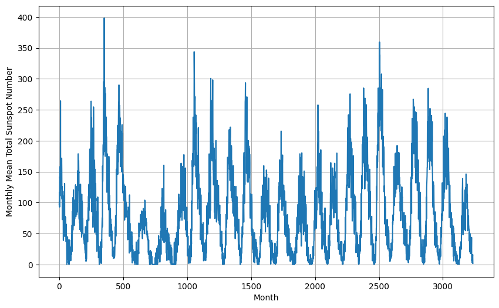

```python
# Initialize lists
time_step = []
sunspots = []

# Open CSV file
with open('./Sunspots.csv') as csvfile:

  # Initialize reader
  reader = csv.reader(csvfile, delimiter=',')

  # Skip the first line
  next(reader)

  # Append row and sunspot number to lists
  for row in reader:
    time_step.append(int(row[0]))
    sunspots.append(float(row[2]))

# Convert lists to numpy arrays
time = np.array(time_step)
series = np.array(sunspots)

# Preview the data
plot_series(time, series, xlabel='Month', ylabel='Monthly Mean Total Sunspot Number')
```

## Split the Dataset

```python
# Define the split time
split_time = 3000

# Get the train set
time_train = time[:split_time]
x_train = series[:split_time]

# Get the validation set
time_valid = time[split_time:]
x_valid = series[split_time:]
```

## Prepare Features and Labels

```python
def windowed_dataset(series, window_size, batch_size, shuffle_buffer):
    """Generates dataset windows

    Args:
      series (array of float) - contains the values of the time series
      window_size (int) - the number of time steps to include in the feature
      batch_size (int) - the batch size
      shuffle_buffer(int) - buffer size to use for the shuffle method

    Returns:
      dataset (TF Dataset) - TF Dataset containing time windows
    """

    # Add an axis for the feature dimension of RNN layers
    series = tf.expand_dims(series, axis=-1)

    # Generate a TF Dataset from the series values
    dataset = tf.data.Dataset.from_tensor_slices(series)

    # Window the data but only take those with the specified size
    dataset = dataset.window(window_size + 1, shift=1, drop_remainder=True)

    # Flatten the windows by putting its elements in a single batch
    dataset = dataset.flat_map(lambda window: window.batch(window_size + 1))

    # Create tuples with features and labels
    dataset = dataset.map(lambda window: (window[:-1], window[-1]))

    # Shuffle the windows
    dataset = dataset.shuffle(shuffle_buffer)

    # Create batches of windows
    dataset = dataset.batch(batch_size)

    # Optimize the dataset for training
    dataset = dataset.cache().prefetch(1)

    return dataset
```

As mentioned in the lectures, if your results don't look good, you can try tweaking the parameters here and see if the model will learn better.

```python
# Parameters
window_size = 30
batch_size = 32
shuffle_buffer_size = 1000

# Generate the dataset windows
train_set = windowed_dataset(x_train, window_size, batch_size, shuffle_buffer_size)
```

## Build the Model

You've seen these layers before and here is how it looks like when combined.

```python
# Build the Model
model = tf.keras.models.Sequential([
    tf.keras.Input(shape=(window_size,1)),
    tf.keras.layers.Conv1D(filters=64, kernel_size=3,
                      strides=1,
                      activation="relu",
                      padding='causal'),
    tf.keras.layers.LSTM(64, return_sequences=True),
    tf.keras.layers.LSTM(64),
    tf.keras.layers.Dense(30, activation="relu"),
    tf.keras.layers.Dense(10, activation="relu"),
    tf.keras.layers.Dense(1),
    tf.keras.layers.Lambda(lambda x: x * 400)
])

 # Print the model summary
model.summary()
```

```
Model: "sequential"
```

```
┏━━━━━━━━━━━━━━━━━━━━━━━━━━━━━━━━━┳━━━━━━━━━━━━━━━━━━━━━━━━┳━━━━━━━━━━━━━━━┓
┃ Layer (type)                    ┃ Output Shape           ┃       Param # ┃
┡━━━━━━━━━━━━━━━━━━━━━━━━━━━━━━━━━╇━━━━━━━━━━━━━━━━━━━━━━━━╇━━━━━━━━━━━━━━━┩
│ conv1d (Conv1D)                 │ (None, 30, 64)         │           256 │
├─────────────────────────────────┼────────────────────────┼───────────────┤
│ lstm (LSTM)                     │ (None, 30, 64)         │        33,024 │
├─────────────────────────────────┼────────────────────────┼───────────────┤
│ lstm_1 (LSTM)                   │ (None, 64)             │        33,024 │
├─────────────────────────────────┼────────────────────────┼───────────────┤
│ dense (Dense)                   │ (None, 30)             │         1,950 │
├─────────────────────────────────┼────────────────────────┼───────────────┤
│ dense_1 (Dense)                 │ (None, 10)             │           310 │
├─────────────────────────────────┼────────────────────────┼───────────────┤
│ dense_2 (Dense)                 │ (None, 1)              │            11 │
├─────────────────────────────────┼────────────────────────┼───────────────┤
│ lambda (Lambda)                 │ (None, 1)              │             0 │
└─────────────────────────────────┴────────────────────────┴───────────────┘
```

```
 Total params: 68,575 (267.87 KB)
```

```
 Trainable params: 68,575 (267.87 KB)
```

```
 Non-trainable params: 0 (0.00 B)
```

## Tune the Learning Rate

As usual, you will want to pick an optimal learning rate.

```python
# Get initial weights
init_weights = model.get_weights()
```

```python
# Set the learning rate scheduler
lr_schedule = tf.keras.callbacks.LearningRateScheduler(
    lambda epoch: 1e-8 * 10**(epoch / 20))

# Initialize the optimizer
optimizer = tf.keras.optimizers.SGD(momentum=0.9)

# Set the training parameters
model.compile(loss=tf.keras.losses.Huber(), optimizer=optimizer)

# Train the model
history = model.fit(train_set, epochs=100, callbacks=[lr_schedule])
```

```
93/93 ━━━━━━━━━━━━━━━━━━━━ 3s 5ms/step - loss: 46.6301 - learning_rate: 1.0000e-08
93/93 ━━━━━━━━━━━━━━━━━━━━ 0s 4ms/step - loss: 44.9357 - learning_rate: 1.1220e-08
93/93 ━━━━━━━━━━━━━━━━━━━━ 0s 4ms/step - loss: 43.5745 - learning_rate: 1.2589e-08
93/93 ━━━━━━━━━━━━━━━━━━━━ 0s 4ms/step - loss: 42.6802 - learning_rate: 1.4125e-08
93/93 ━━━━━━━━━━━━━━━━━━━━ 0s 4ms/step - loss: 41.8557 - learning_rate: 1.5849e-08
93/93 ━━━━━━━━━━━━━━━━━━━━ 0s 4ms/step - loss: 41.0677 - learning_rate: 1.7783e-08
93/93 ━━━━━━━━━━━━━━━━━━━━ 0s 4ms/step - loss: 40.2823 - learning_rate: 1.9953e-08
93/93 ━━━━━━━━━━━━━━━━━━━━ 0s 4ms/step - loss: 39.5021 - learning_rate: 2.2387e-08
93/93 ━━━━━━━━━━━━━━━━━━━━ 0s 4ms/step - loss: 38.7111 - learning_rate: 2.5119e-08
93/93 ━━━━━━━━━━━━━━━━━━━━ 0s 4ms/step - loss: 37.8778 - learning_rate: 2.8184e-08
93/93 ━━━━━━━━━━━━━━━━━━━━ 0s 4ms/step - loss: 36.9131 - learning_rate: 3.1623e-08
93/93 ━━━━━━━━━━━━━━━━━━━━ 0s 4ms/step - loss: 35.7305 - learning_rate: 3.5481e-08
93/93 ━━━━━━━━━━━━━━━━━━━━ 0s 4ms/step - loss: 34.6146 - learning_rate: 3.9811e-08
93/93 ━━━━━━━━━━━━━━━━━━━━ 0s 4ms/step - loss: 33.5262 - learning_rate: 4.4668e-08
93/93 ━━━━━━━━━━━━━━━━━━━━ 0s 4ms/step - loss: 32.4430 - learning_rate: 5.0119e-08
93/93 ━━━━━━━━━━━━━━━━━━━━ 0s 4ms/step - loss: 31.3676 - learning_rate: 5.6234e-08
93/93 ━━━━━━━━━━━━━━━━━━━━ 0s 4ms/step - loss: 30.4817 - learning_rate: 6.3096e-08
93/93 ━━━━━━━━━━━━━━━━━━━━ 0s 4ms/step - loss: 29.5681 - learning_rate: 7.0795e-08
93/93 ━━━━━━━━━━━━━━━━━━━━ 0s 4ms/step - loss: 28.5688 - learning_rate: 7.9433e-08
93/93 ━━━━━━━━━━━━━━━━━━━━ 0s 4ms/step - loss: 27.4822 - learning_rate: 8.9125e-08
93/93 ━━━━━━━━━━━━━━━━━━━━ 0s 4ms/step - loss: 26.5376 - learning_rate: 1.0000e-07
93/93 ━━━━━━━━━━━━━━━━━━━━ 0s 4ms/step - loss: 25.5747 - learning_rate: 1.1220e-07
93/93 ━━━━━━━━━━━━━━━━━━━━ 0s 4ms/step - loss: 24.6172 - learning_rate: 1.2589e-07
93/93 ━━━━━━━━━━━━━━━━━━━━ 0s 4ms/step - loss: 23.6779 - learning_rate: 1.4125e-07
93/93 ━━━━━━━━━━━━━━━━━━━━ 0s 4ms/step - loss: 22.8046 - learning_rate: 1.5849e-07
93/93 ━━━━━━━━━━━━━━━━━━━━ 0s 4ms/step - loss: 22.1112 - learning_rate: 1.7783e-07
93/93 ━━━━━━━━━━━━━━━━━━━━ 0s 4ms/step - loss: 21.5032 - learning_rate: 1.9953e-07
93/93 ━━━━━━━━━━━━━━━━━━━━ 0s 4ms/step - loss: 20.9637 - learning_rate: 2.2387e-07
93/93 ━━━━━━━━━━━━━━━━━━━━ 0s 4ms/step - loss: 20.5714 - learning_rate: 2.5119e-07
93/93 ━━━━━━━━━━━━━━━━━━━━ 0s 4ms/step - loss: 20.1957 - learning_rate: 2.8184e-07
93/93 ━━━━━━━━━━━━━━━━━━━━ 0s 4ms/step - loss: 19.9951 - learning_rate: 3.1623e-07
93/93 ━━━━━━━━━━━━━━━━━━━━ 0s 4ms/step - loss: 19.8934 - learning_rate: 3.5481e-07
93/93 ━━━━━━━━━━━━━━━━━━━━ 0s 4ms/step - loss: 19.8676 - learning_rate: 3.9811e-07
93/93 ━━━━━━━━━━━━━━━━━━━━ 0s 4ms/step - loss: 19.4121 - learning_rate: 4.4668e-07
93/93 ━━━━━━━━━━━━━━━━━━━━ 0s 4ms/step - loss: 19.1286 - learning_rate: 5.0119e-07
93/93 ━━━━━━━━━━━━━━━━━━━━ 0s 4ms/step - loss: 18.9326 - learning_rate: 5.6234e-07
93/93 ━━━━━━━━━━━━━━━━━━━━ 0s 4ms/step - loss: 18.8238 - learning_rate: 6.3096e-07
93/93 ━━━━━━━━━━━━━━━━━━━━ 0s 4ms/step - loss: 19.1922 - learning_rate: 7.0795e-07
93/93 ━━━━━━━━━━━━━━━━━━━━ 0s 4ms/step - loss: 18.8190 - learning_rate: 7.9433e-07
93/93 ━━━━━━━━━━━━━━━━━━━━ 0s 4ms/step - loss: 18.3363 - learning_rate: 8.9125e-07
```

[output cut: 45 more lines]

```
93/93 ━━━━━━━━━━━━━━━━━━━━ 0s 4ms/step - loss: 30.2247 - learning_rate: 1.7783e-04
93/93 ━━━━━━━━━━━━━━━━━━━━ 0s 4ms/step - loss: 33.5329 - learning_rate: 1.9953e-04
93/93 ━━━━━━━━━━━━━━━━━━━━ 0s 4ms/step - loss: 33.6691 - learning_rate: 2.2387e-04
93/93 ━━━━━━━━━━━━━━━━━━━━ 0s 4ms/step - loss: 31.6961 - learning_rate: 2.5119e-04
93/93 ━━━━━━━━━━━━━━━━━━━━ 0s 4ms/step - loss: 43.0452 - learning_rate: 2.8184e-04
93/93 ━━━━━━━━━━━━━━━━━━━━ 0s 4ms/step - loss: 47.1326 - learning_rate: 3.1623e-04
93/93 ━━━━━━━━━━━━━━━━━━━━ 0s 4ms/step - loss: 51.0992 - learning_rate: 3.5481e-04
93/93 ━━━━━━━━━━━━━━━━━━━━ 0s 4ms/step - loss: 58.3860 - learning_rate: 3.9811e-04
93/93 ━━━━━━━━━━━━━━━━━━━━ 0s 4ms/step - loss: 56.6061 - learning_rate: 4.4668e-04
93/93 ━━━━━━━━━━━━━━━━━━━━ 0s 4ms/step - loss: 61.0482 - learning_rate: 5.0119e-04
93/93 ━━━━━━━━━━━━━━━━━━━━ 0s 4ms/step - loss: 63.5604 - learning_rate: 5.6234e-04
93/93 ━━━━━━━━━━━━━━━━━━━━ 0s 4ms/step - loss: 60.2895 - learning_rate: 6.3096e-04
93/93 ━━━━━━━━━━━━━━━━━━━━ 0s 4ms/step - loss: 63.9995 - learning_rate: 7.0795e-04
93/93 ━━━━━━━━━━━━━━━━━━━━ 0s 4ms/step - loss: 57.3688 - learning_rate: 7.9433e-04
93/93 ━━━━━━━━━━━━━━━━━━━━ 0s 4ms/step - loss: 62.2880 - learning_rate: 8.9125e-04
```

```
(1e-08, 0.001, 0.0, 100.0)
```

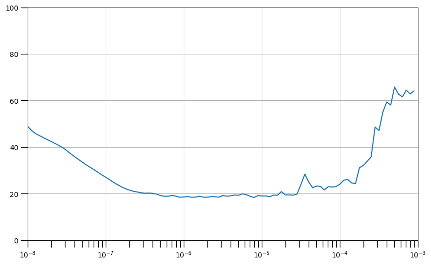

```python
# Define the learning rate array
lrs = 1e-8 * (10 ** (np.arange(100) / 20))

# Set the figure size
plt.figure(figsize=(10, 6))

# Set the grid
plt.grid(True)

# Plot the loss in log scale
plt.semilogx(lrs, history.history["loss"])

# Increase the tickmarks size
plt.tick_params('both', length=10, width=1, which='both')

# Set the plot boundaries
plt.axis([1e-8, 1e-3, 0, 100])
```

## Train the Model

Now you can proceed to reset and train the model. It is set for 100 epochs in the cell below but feel free to increase it if you want. Laurence got his results in the lectures after 500.

```python
# Reset states generated by Keras
tf.keras.backend.clear_session()

# Reset the weights
model.set_weights(init_weights)
```

```python
# Set the learning rate
learning_rate = 8e-7

# Set the optimizer
optimizer = tf.keras.optimizers.SGD(learning_rate=learning_rate, momentum=0.9)

# Set the training parameters
model.compile(loss=tf.keras.losses.Huber(),
              optimizer=optimizer,
              metrics=["mae"])
```

```python
# Train the model
history = model.fit(train_set,epochs=100)
```

```
93/93 ━━━━━━━━━━━━━━━━━━━━ 2s 4ms/step - loss: 39.6136 - mae: 40.1081
93/93 ━━━━━━━━━━━━━━━━━━━━ 0s 4ms/step - loss: 25.9470 - mae: 26.4412
93/93 ━━━━━━━━━━━━━━━━━━━━ 0s 4ms/step - loss: 21.9388 - mae: 22.4321
93/93 ━━━━━━━━━━━━━━━━━━━━ 0s 4ms/step - loss: 20.5369 - mae: 21.0293
93/93 ━━━━━━━━━━━━━━━━━━━━ 0s 4ms/step - loss: 19.6171 - mae: 20.1084
93/93 ━━━━━━━━━━━━━━━━━━━━ 0s 4ms/step - loss: 19.0719 - mae: 19.5636
93/93 ━━━━━━━━━━━━━━━━━━━━ 0s 4ms/step - loss: 18.8906 - mae: 19.3818
93/93 ━━━━━━━━━━━━━━━━━━━━ 0s 4ms/step - loss: 18.4057 - mae: 18.8981
93/93 ━━━━━━━━━━━━━━━━━━━━ 0s 4ms/step - loss: 18.3848 - mae: 18.8761
93/93 ━━━━━━━━━━━━━━━━━━━━ 0s 4ms/step - loss: 18.1387 - mae: 18.6297
93/93 ━━━━━━━━━━━━━━━━━━━━ 0s 4ms/step - loss: 18.1928 - mae: 18.6848
93/93 ━━━━━━━━━━━━━━━━━━━━ 0s 4ms/step - loss: 17.9367 - mae: 18.4281
93/93 ━━━━━━━━━━━━━━━━━━━━ 0s 4ms/step - loss: 18.0193 - mae: 18.5110
93/93 ━━━━━━━━━━━━━━━━━━━━ 0s 4ms/step - loss: 17.8187 - mae: 18.3084
93/93 ━━━━━━━━━━━━━━━━━━━━ 0s 4ms/step - loss: 17.8371 - mae: 18.3261
93/93 ━━━━━━━━━━━━━━━━━━━━ 0s 4ms/step - loss: 18.0575 - mae: 18.5479
93/93 ━━━━━━━━━━━━━━━━━━━━ 0s 4ms/step - loss: 17.6693 - mae: 18.1608
93/93 ━━━━━━━━━━━━━━━━━━━━ 0s 4ms/step - loss: 17.6179 - mae: 18.1082
93/93 ━━━━━━━━━━━━━━━━━━━━ 0s 4ms/step - loss: 17.5495 - mae: 18.0394
93/93 ━━━━━━━━━━━━━━━━━━━━ 0s 4ms/step - loss: 17.7358 - mae: 18.2272
93/93 ━━━━━━━━━━━━━━━━━━━━ 0s 4ms/step - loss: 17.4467 - mae: 17.9387
93/93 ━━━━━━━━━━━━━━━━━━━━ 0s 4ms/step - loss: 17.4295 - mae: 17.9234
93/93 ━━━━━━━━━━━━━━━━━━━━ 0s 4ms/step - loss: 17.4873 - mae: 17.9797
93/93 ━━━━━━━━━━━━━━━━━━━━ 0s 4ms/step - loss: 17.5421 - mae: 18.0328
93/93 ━━━━━━━━━━━━━━━━━━━━ 0s 4ms/step - loss: 17.2417 - mae: 17.7329
93/93 ━━━━━━━━━━━━━━━━━━━━ 0s 4ms/step - loss: 17.2615 - mae: 17.7527
93/93 ━━━━━━━━━━━━━━━━━━━━ 0s 4ms/step - loss: 17.2314 - mae: 17.7220
93/93 ━━━━━━━━━━━━━━━━━━━━ 0s 4ms/step - loss: 17.2866 - mae: 17.7775
93/93 ━━━━━━━━━━━━━━━━━━━━ 0s 4ms/step - loss: 17.1964 - mae: 17.6858
93/93 ━━━━━━━━━━━━━━━━━━━━ 0s 4ms/step - loss: 17.1704 - mae: 17.6596
93/93 ━━━━━━━━━━━━━━━━━━━━ 0s 4ms/step - loss: 17.1255 - mae: 17.6134
93/93 ━━━━━━━━━━━━━━━━━━━━ 0s 4ms/step - loss: 17.1940 - mae: 17.6835
93/93 ━━━━━━━━━━━━━━━━━━━━ 0s 4ms/step - loss: 17.4106 - mae: 17.9030
93/93 ━━━━━━━━━━━━━━━━━━━━ 0s 4ms/step - loss: 17.4589 - mae: 17.9484
93/93 ━━━━━━━━━━━━━━━━━━━━ 0s 4ms/step - loss: 17.2509 - mae: 17.7417
93/93 ━━━━━━━━━━━━━━━━━━━━ 0s 4ms/step - loss: 17.2322 - mae: 17.7241
93/93 ━━━━━━━━━━━━━━━━━━━━ 0s 4ms/step - loss: 17.2800 - mae: 17.7701
93/93 ━━━━━━━━━━━━━━━━━━━━ 0s 4ms/step - loss: 17.1179 - mae: 17.6078
93/93 ━━━━━━━━━━━━━━━━━━━━ 0s 4ms/step - loss: 17.2415 - mae: 17.7345
93/93 ━━━━━━━━━━━━━━━━━━━━ 0s 4ms/step - loss: 17.1465 - mae: 17.6383
```

[output cut: 45 more lines]

```
93/93 ━━━━━━━━━━━━━━━━━━━━ 0s 4ms/step - loss: 16.7003 - mae: 17.1883
93/93 ━━━━━━━━━━━━━━━━━━━━ 0s 4ms/step - loss: 16.6903 - mae: 17.1794
93/93 ━━━━━━━━━━━━━━━━━━━━ 0s 4ms/step - loss: 16.7908 - mae: 17.2813
93/93 ━━━━━━━━━━━━━━━━━━━━ 0s 4ms/step - loss: 16.6933 - mae: 17.1829
93/93 ━━━━━━━━━━━━━━━━━━━━ 0s 4ms/step - loss: 16.8816 - mae: 17.3725
93/93 ━━━━━━━━━━━━━━━━━━━━ 0s 4ms/step - loss: 16.8006 - mae: 17.2887
93/93 ━━━━━━━━━━━━━━━━━━━━ 0s 4ms/step - loss: 16.7060 - mae: 17.1929
93/93 ━━━━━━━━━━━━━━━━━━━━ 0s 4ms/step - loss: 16.7256 - mae: 17.2167
93/93 ━━━━━━━━━━━━━━━━━━━━ 0s 4ms/step - loss: 16.7363 - mae: 17.2279
93/93 ━━━━━━━━━━━━━━━━━━━━ 0s 4ms/step - loss: 16.7158 - mae: 17.2047
93/93 ━━━━━━━━━━━━━━━━━━━━ 0s 4ms/step - loss: 16.8175 - mae: 17.3087
93/93 ━━━━━━━━━━━━━━━━━━━━ 0s 4ms/step - loss: 16.6731 - mae: 17.1622
93/93 ━━━━━━━━━━━━━━━━━━━━ 0s 4ms/step - loss: 16.6614 - mae: 17.1494
93/93 ━━━━━━━━━━━━━━━━━━━━ 0s 4ms/step - loss: 16.6851 - mae: 17.1756
93/93 ━━━━━━━━━━━━━━━━━━━━ 0s 4ms/step - loss: 16.6527 - mae: 17.1410
```

You can visualize the training and see if the loss and MAE are still trending down.

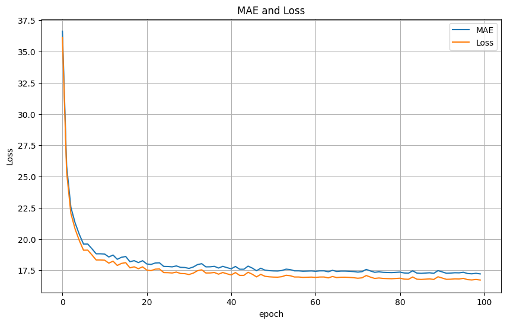

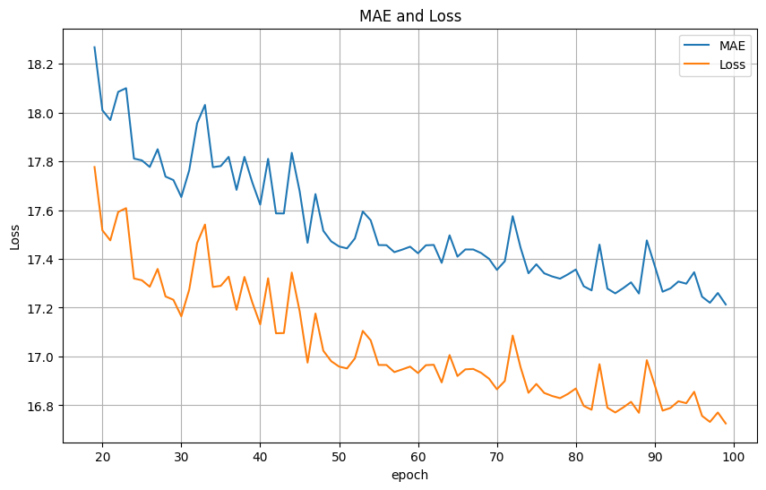

```python
# Get mae and loss from history log
mae=history.history['mae']
loss=history.history['loss']

# Get number of epochs
epochs=range(len(loss))

# Plot mae and loss
plot_series(
    x=epochs,
    y=(mae, loss),
    title='MAE and Loss',
    xlabel='epoch',
    ylabel='Loss',
    legend=['MAE', 'Loss']
    )

# Only plot the last 80% of the epochs
zoom_split = int(epochs[-1] * 0.2)
epochs_zoom = epochs[zoom_split:]
mae_zoom = mae[zoom_split:]
loss_zoom = loss[zoom_split:]

# Plot zoomed mae and loss
plot_series(
    x=epochs_zoom,
    y=(mae_zoom, loss_zoom),
    title='MAE and Loss',
    xlabel='epoch',
    ylabel='Loss',
    legend=['MAE', 'Loss']
    )
```

## Model Prediction

As before, you can get the predictions for the validation set time range and compute the metrics.

```python
def model_forecast(model, series, window_size, batch_size):
    """Uses an input model to generate predictions on data windows

    Args:
      model (TF Keras Model) - model that accepts data windows
      series (array of float) - contains the values of the time series
      window_size (int) - the number of time steps to include in the window
      batch_size (int) - the batch size

    Returns:
      forecast (numpy array) - array containing predictions
    """

    # Add an axis for the feature dimension of RNN layers
    series = tf.expand_dims(series, axis=-1)

    # Generate a TF Dataset from the series values
    dataset = tf.data.Dataset.from_tensor_slices(series)

    # Window the data but only take those with the specified size
    dataset = dataset.window(window_size, shift=1, drop_remainder=True)

    # Flatten the windows by putting its elements in a single batch
    dataset = dataset.flat_map(lambda w: w.batch(window_size))

    # Create batches of windows
    dataset = dataset.batch(batch_size).prefetch(1)

    # Get predictions on the entire dataset
    forecast = model.predict(dataset, verbose=0)

    return forecast
```

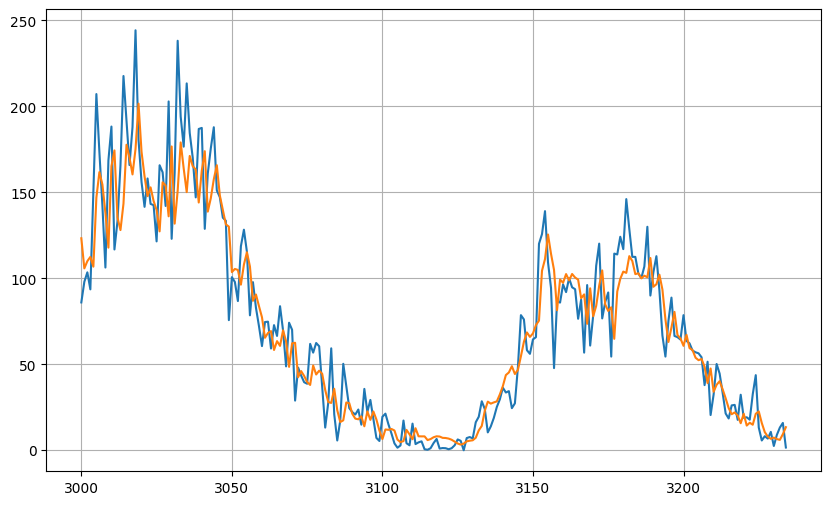

```python
# Reduce the original series
forecast_series = series[split_time-window_size:-1]

# Use helper function to generate predictions
forecast = model_forecast(model, forecast_series, window_size, batch_size)

# Drop single dimensional axis
results = forecast.squeeze()

# Plot the results
plot_series(time_valid, (x_valid, results))
```

```python
# Compute the MAE
print(tf.keras.metrics.mae(x_valid, results).numpy())
```

```
14.527155
```

## Wrap Up

This concludes the final practice lab for this course! You implemented a deep and complex architecture composed of CNNs, RNNs, and DNNs. You'll be using the skills you developed throughout this course to complete the final assignment. Keep it up!